# Machine Learning Project

Lawrence Goh

Tuesday, 12 May 2015

This project entails processing a dataset to use a set of predictors (from sensors) to predict the required outcome which is the quality of the weightlift (variable: classe). This is done through the use of a huge training data set of about 19000 samples and 160 variables. The aim through pre-processing to get as best a fit of a machine learning model to fit the testing set. There is also a need to estimate the out of sample error. For the model used (Random Forest), the estimated error is taken as 1 - Kappa value. In this case, the out of sample error is 0.0026.

### Part 1: Reading in the data set and using Excel to search and replace with 0 all missing, NA and DIV/0 values

```r
library(caret); library(ggplot2)
set.seed(1)
# assume the file pml-training.csv is already downloaded to this current dir
tr <- read.csv('pml-training.csv')

# convert to numeric
tr$kurtosis_roll_arm = as.numeric(tr$kurtosis_roll_arm)
tr$kurtosis_roll_belt = as.numeric(tr$kurtosis_roll_belt)
tr$kurtosis_picth_belt = as.numeric(tr$kurtosis_picth_belt)
tr$kurtosis_yaw_belt = as.numeric(tr$kurtosis_yaw_belt)
tr$skewness_roll_belt = as.numeric(tr$skewness_roll_belt)
tr$skewness_roll_belt.1 = as.numeric(tr$skewness_roll_belt.1)
tr$skewness_yaw_belt = as.numeric(tr$skewness_yaw_belt)
tr$max_yaw_belt = as.numeric(tr$max_yaw_belt)
tr$min_yaw_belt = as.numeric(tr$min_yaw_belt)
tr$amplitude_yaw_belt = as.numeric(tr$amplitude_yaw_belt)
tr$amplitude_yaw_dumbbell = as.numeric(tr$amplitude_yaw_dumbbell)
tr$min_yaw_dumbbell = as.numeric(tr$min_yaw_dumbbell)
tr$max_yaw_dumbbell = as.numeric(tr$max_yaw_dumbbell)
tr$skewness_yaw_dumbbell = as.numeric(tr$skewness_yaw_dumbbell)
tr$skewness_pitch_dumbbell = as.numeric(tr$skewness_pitch_dumbbell)
tr$skewness_roll_dumbbell = as.numeric(tr$skewness_roll_dumbbell)
tr$kurtosis_yaw_dumbbell = as.numeric(tr$kurtosis_yaw_dumbbell)
tr$kurtosis_picth_dumbbell = as.numeric(tr$kurtosis_picth_dumbbell)
tr$kurtosis_roll_dumbbell = as.numeric(tr$skewness_roll_dumbbell)
tr$skewness_yaw_arm = as.numeric(tr$skewness_yaw_arm)
tr$skewness_roll_arm = as.numeric(tr$skewness_roll_arm)
tr$kurtosis_yaw_arm = as.numeric(tr$kurtosis_yaw_arm)
tr$kurtosis_picth_arm = as.numeric(tr$kurtosis_picth_arm)
tr$skewness_pitch_arm = as.numeric(tr$skewness_pitch_arm)
tr$amplitude_yaw_forearm = as.numeric(tr$amplitude_yaw_forearm)
tr$skewness_yaw_forearm = as.numeric(tr$skewness_yaw_forearm)
tr$skewness_pitch_forearm = as.numeric(tr$skewness_pitch_forearm)
tr$skewness_roll_forearm = as.numeric(tr$skewness_roll_forearm)
tr$kurtosis_yaw_forearm = as.numeric(tr$kurtosis_yaw_forearm)
tr$kurtosis_picth_forearm = as.numeric(tr$kurtosis_picth_forearm)
tr$kurtosis_roll_forearm = as.numeric(tr$kurtosis_roll_forearm)
tr$max_yaw_forearm = as.numeric(tr$max_yaw_forearm)
tr$min_yaw_forearm = as.numeric(tr$min_yaw_forearm)

# deriving the classes from the training set, to read in testing set
classes <- sapply(tr, class)
classes <- classes[-length(classes)]
classes [['problem_id']]<-"numeric"
te <- read.csv('pml-testing.csv',colClasses=classes, quote = "\"")
```

### Part 2: Remove some predictors from the training and final test set

```r
# take out first 5 predictors since not meaningful to predict outcome (serial no, user_name, timestamps)
tr <- tr[,-c(1:5)]
te <- te[,-c(1:5)]

# do this step to remove near Zero variance predictors
nZV <- nearZeroVar(tr)
tr <- tr[, -nZV]
te <- te[, -nZV]

# remove high correlated predictors, above 90%
desCor <- cor(tr[,-54])
highCor <- findCorrelation(desCor,0.90)
tr <- tr[,-highCor]
te <- te[,-highCor]

# select column names from training set minus last one which is the outcome
te <- te[,(names(tr)[-length(names(tr))])]

# split test vs training, using 85% for training
train.index <- createDataPartition (y = tr$classe, p = 0.85, list = F)
training <- tr [ train.index, ]
testing  <- tr [-train.index, ]
```

### Part 3: Do Cross Validation using 3 folds and 2 repeats, do Machine Learning using Random forest model

```r
# configure with cross validation 3 K folds, repeated 2 times
bootControl <- trainControl(method = "repeatedcv",number = 3,repeats = 2)

# Fit Random Forest model with pre processing to scale and center with 200 trees
modFit<-train(classe ~ ., data=training, method="rf", ntree=200,importance=T,do.trace = 10033, trControl = bootControl, preProcess = c("scale","center"),na.action=na.omit)
#---------- Final Model ----------
print(modFit$finalModel)
```

```
##
## Call:
##  randomForest(x = x, y = y, ntree = 200, mtry = param$mtry, importance = ..2,      do.trace = 10033)
##                Type of random forest: classification
##                      Number of trees: 200
## No. of variables tried at each split: 24
##
##         OOB estimate of  error rate: 0.18%
## Confusion matrix:
##      A    B    C    D    E class.error
## A 4741    1    0    0    1 0.000421674
## B    6 3220    2    0    0 0.002478315
## C    0    5 2903    1    0 0.002062564
## D    0    0    9 2724    1 0.003657644
## E    0    0    0    4 3062 0.001304631
```

```r
#---------- Test of Accuracy and Out of Sample Estimate ----------
pred<-predict(modFit,testing)
print(confusionMatrix(pred,testing$classe))
```

```
## Confusion Matrix and Statistics
##
##           Reference
## Prediction   A   B   C   D   E
##          A 837   2   0   0   0
##          B   0 567   2   0   0
##          C   0   0 511   2   0
##          D   0   0   0 480   0
##          E   0   0   0   0 541
##
## Overall Statistics
##
##                Accuracy : 0.998
##                  95% CI : (0.9956, 0.9993)
##     No Information Rate : 0.2845
##     P-Value [Acc > NIR] : < 2.2e-16
##
##                   Kappa : 0.9974
##  Mcnemar's Test P-Value : NA
##
## Statistics by Class:
##
##                      Class: A Class: B Class: C Class: D Class: E
## Sensitivity            1.0000   0.9965   0.9961   0.9959   1.0000
## Specificity            0.9990   0.9992   0.9992   1.0000   1.0000
## Pos Pred Value         0.9976   0.9965   0.9961   1.0000   1.0000
## Neg Pred Value         1.0000   0.9992   0.9992   0.9992   1.0000
## Prevalence             0.2845   0.1934   0.1744   0.1638   0.1839
## Detection Rate         0.2845   0.1927   0.1737   0.1632   0.1839
## Detection Prevalence   0.2852   0.1934   0.1744   0.1632   0.1839
## Balanced Accuracy      0.9995   0.9978   0.9976   0.9979   1.0000
```

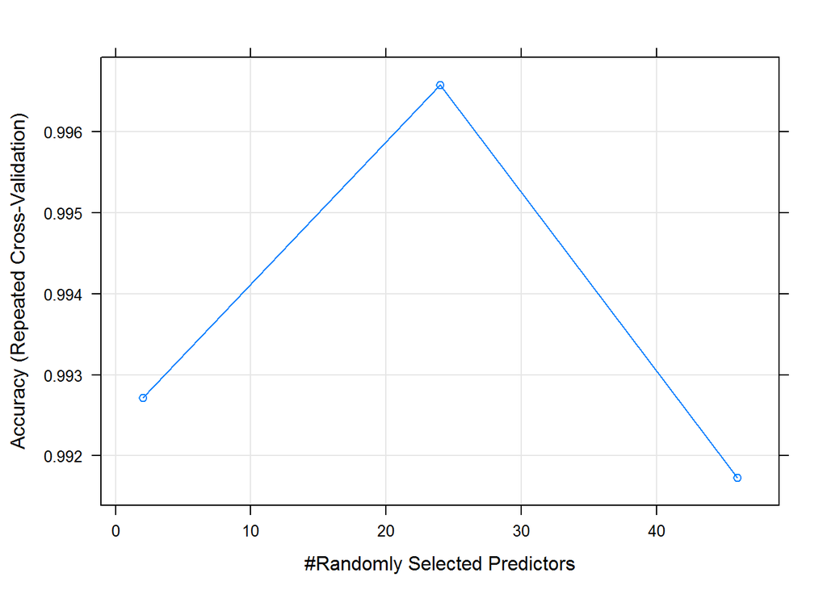

```r
print(plot.train(modFit))
```

### Part 4: Using the fitted model to predict the 20 test cases

```r
# Predict using the real testing data
te.pred<-predict(modFit,te)
print(te.pred)
```

```
##  [1] B A B A A E D B A A B C B A E E A B B B
## Levels: A B C D E
```

```r
pml_write_files = function(x){
        n = length(x)
        for(i in 1:n){
                filename = paste0("./","problem_id_",i,".txt")
                write.table(x[i],file=filename,quote=FALSE,row.names=FALSE,col.names=FALSE)
        }
}

pml_write_files(te.pred)
```

### Useful Exploratory plots

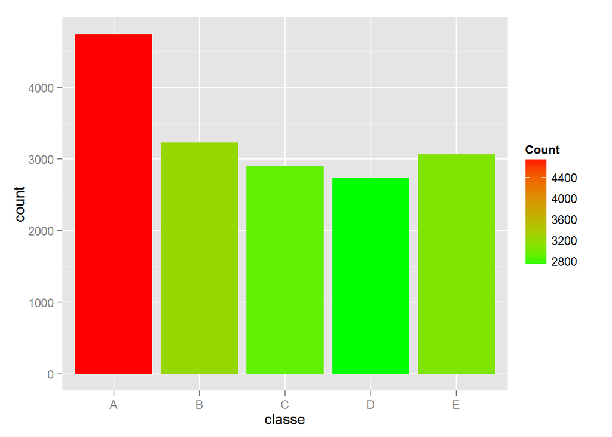

```r
# histogram of testing data, shows most training data at which classe
m<- ggplot(training,aes(x=classe))
m+geom_histogram(aes(fill = ..count..))+scale_fill_gradient("Count", low = "green", high = "red")
```